# R Notebook

```r
library(tidyverse)
library(tidycensus)
library(janitor)
library(tesseract)
library(magick)
library(tidycensus)
```

1. Loading and cleaning

```r
#load my education data
md_ed_counties <- read_csv("choose_md_compare_counties.csv")
```

```r
#load racial demographics
acs5_variables <- load_variables(2021, "acs5", cache = TRUE)
md_racial_demographics <- get_acs(geography = "county",
              variables = c(total_race = "B02001_001", white = "B02001_002", black = "B02001_003", american_indian = "B02001_004", asian = "B02001_005", native_hawaiian_pi = "B02001_006", latino = "B03002_012", med_income = "B19013_001"),
              state = "MD",
              year = 2021)
```

Fyi - chatgpt helped me do this. i gave it some examples of my dataframe (before we went over this in class) and then told it how I wanted the data to look.

```r
#clean racial demographics to make it easier to read/joinable

#chatgpt helped me do this
md_racial_demographics_wide <- md_racial_demographics |>
  pivot_wider(names_from = variable, values_from = estimate)
```

```r
md_racial_demographics_grouped <- md_racial_demographics_wide |>
  select(-moe) |>
  group_by(NAME, GEOID)

#chatgpt helped me here as well - took a few tries to get the data to show up correctly.
md_demographics_consolidated <- md_racial_demographics_grouped |>
  mutate(across(everything(), ~ if (is.numeric(.)) sum(., na.rm = TRUE) else first(.))) |>
  slice(1)  # Keep only one row per county
#why am i getting an x but it's still running?
```

```r
md_demographics_consolidated <- md_demographics_consolidated |>
  rename(County = NAME) |>
  mutate(County = str_to_title(str_remove_all(County,", Maryland"))) |>
  mutate(County = str_trim(County,side="both"))
```

```r
#now let's join!
education_and_racial_demographics <- md_ed_counties |> inner_join(md_demographics_consolidated, join_by(County))
```

```r
#now I need to clean and join my CTE and graduation rates data
grad_rates_cte <- read_csv("md_hs_grad_rates_cte.csv")
ed_data_demographics_total <- education_and_racial_demographics |> inner_join(grad_rates_cte, join_by(County))

ed_data_demographics_total <- ed_data_demographics_total |>
  clean_names()

ed_data_demographics_total <- ed_data_demographics_total |>
   rename(pub_expenditure = public_school_expenditures_per_pupil_dollars,
         number_hs_grads = annual_number_of_public_high_school_graduates,
         cte_participation_pct = x2022_45_percent_goal_attainment_cte_participation) |>
  mutate(pct_white = white/total_race*100,
         pct_black = black/total_race*100,
         pct_latino = latino/total_race*100,
         pct_asian = asian/total_race*100) |>
  mutate(cte_participation_pct = str_remove_all(cte_participation_pct, "%"))
```

1. Profile of my data I chose an unfortunately complicated dataset. My original dataset is provided by the Maryland Department of Commerce. It includes a hodgepodge of different data pieces from different years compiled by the dept of commerce. The original source of these data points come from the Maryland State Department of Education, the Maryland Higher Education Commission and the Census. Data years are the 2017-18, 2018, 2019, and then the census data spans 2014-2018. All in all, a bit chaotic. Also unclear what the dept. of commerce is using this data for.

I added census data on racial demographics and median income from 2021. I also added graduation rates for 2021, college enrollment rates for the classes of 2019 and 2021, and CTE participation rates by count for the class of 2022 from the Maryland State Dept of Education. Mine is all aggregate data, but I don’t have access to the original data to check it.

2. Data Exploration

First, I want to look at the relationship between expenditure per pupil and other factors. Let’s start by looking at which counties spend the most on their students compared to median income.

```r
ggplot(ed_data_demographics_total, aes(x=pub_expenditure, y=med_income)) +
  geom_point()
```

[output not shown]

Looks like there isn’t a strong relationship between a county’s median income and how much schools spend on students. Next, let’s look at how expenditure per pupil relates to high school graduation rates.

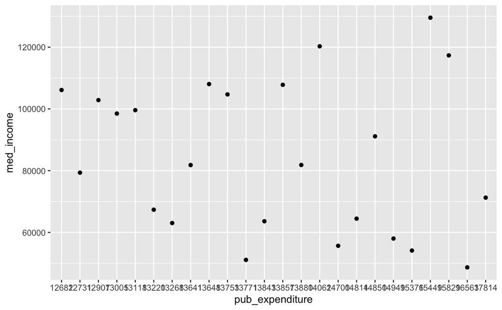

```r
ggplot(ed_data_demographics_total, aes(x=pub_expenditure, y=med_income)) +
  geom_point()
```

```r
NA
NA
```

This is interesting. It looks like school districts that spend the least on their students have high graduation rates. The lower grad rates come from districts that spend a medium to high amount on their students. Let’s see how median income impacts graduation rates.

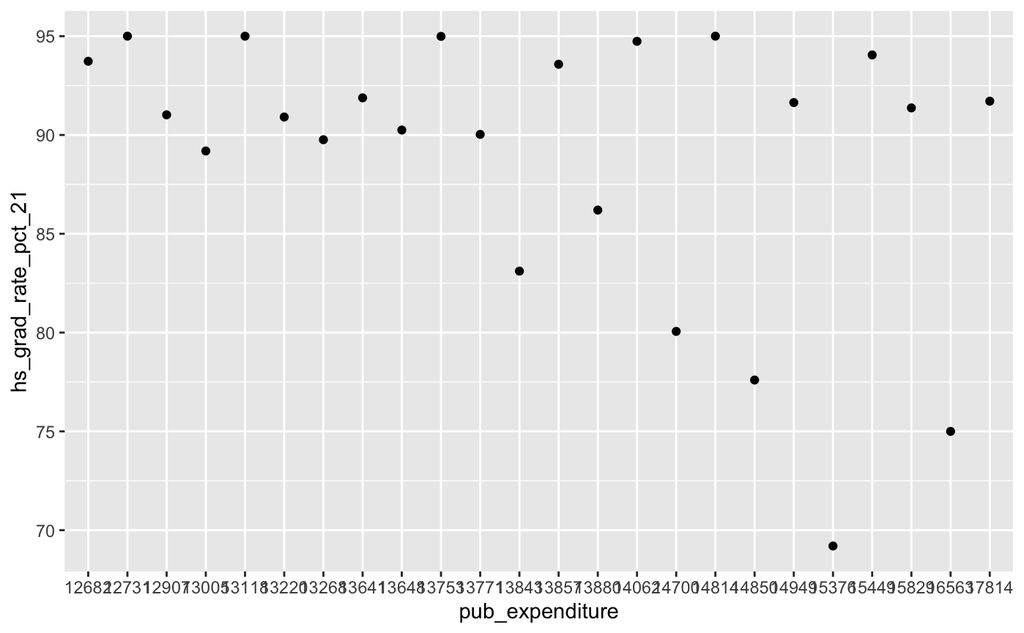

```r
ggplot(ed_data_demographics_total, aes(x=pub_expenditure, y=hs_grad_rate_pct_21)) +
  geom_point()
```

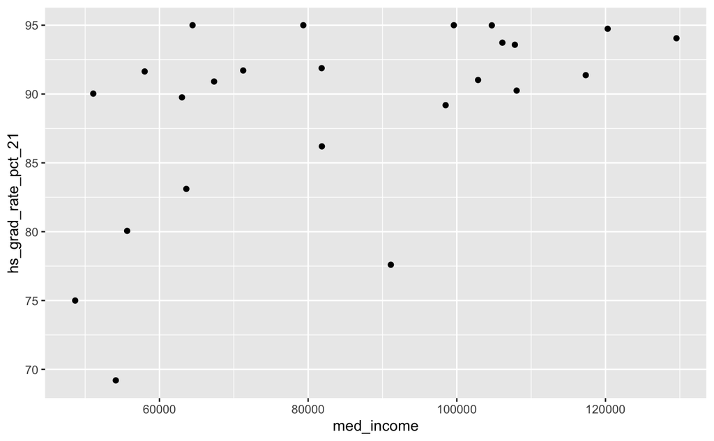

```r
ggplot(ed_data_demographics_total, aes(x=med_income, y=hs_grad_rate_pct_21)) +
  geom_point()
```

What I want to know is what schools with low graduation rates have in common. Let’s check racial demographics and CTE participation.

```r
ggplot(ed_data_demographics_total, aes(x=cte_participation_pct, y=hs_grad_rate_pct_21)) +
  geom_point()
```

[output not shown]

Let’s look at racial demographics.

```r
ggplot(ed_data_demographics_total, aes(x=pct_white, y=hs_grad_rate_pct_21)) +
  geom_point()

ggplot(ed_data_demographics_total, aes(x=pct_black, y=hs_grad_rate_pct_21)) +
  geom_point()

ggplot(ed_data_demographics_total, aes(x=pct_latino, y=hs_grad_rate_pct_21)) +
  geom_point()

ggplot(ed_data_demographics_total, aes(x=pct_asian, y=hs_grad_rate_pct_21)) +
  geom_point()
```

[output not shown]

Next, I’d like to look at CTE participation. Let’s make a map showing how CTE participation varies depending on the county. Here’s the link to my datawrapper map: https://datawrapper.dwcdn.net/aGYwg/1/

```r
write_csv(ed_data_demographics_total, "ed_data_demographics_total.csv")
knitr::include_graphics("cte_map.png")
```

[output not shown]

What factors impact CTE participation? let’s do the same thing we just did with graduation rates.

```r
ggplot(ed_data_demographics_total, aes(x=pct_white, y=cte_participation_pct)) +
  geom_point()

ggplot(ed_data_demographics_total, aes(x=pct_black, y=cte_participation_pct)) +
  geom_point()

ggplot(ed_data_demographics_total, aes(x=pct_latino, y=cte_participation_pct)) +
  geom_point()

ggplot(ed_data_demographics_total, aes(x=med_income, y=cte_participation_pct)) +
  geom_point()

ggplot(ed_data_demographics_total, aes(x=pub_expenditure, y=cte_participation_pct)) +
  geom_point()

ggplot(ed_data_demographics_total, aes(x=public_school_student_teacher_ratio, y=cte_participation_pct)) +
  geom_point()
```

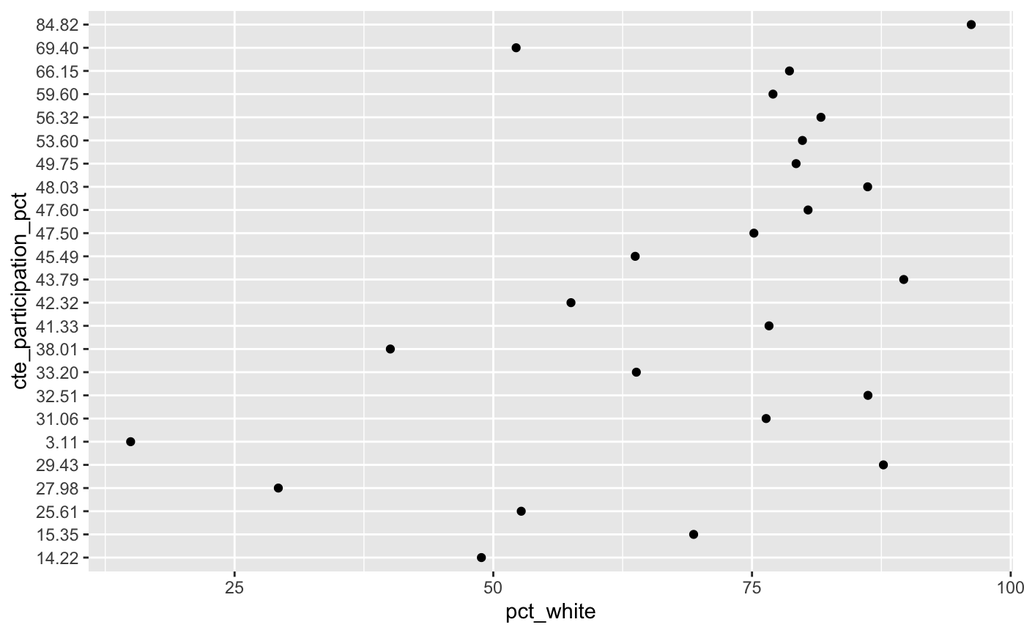

```r
ggplot(ed_data_demographics_total, aes(x=pct_white, y=cte_participation_pct)) +
  geom_point()
```

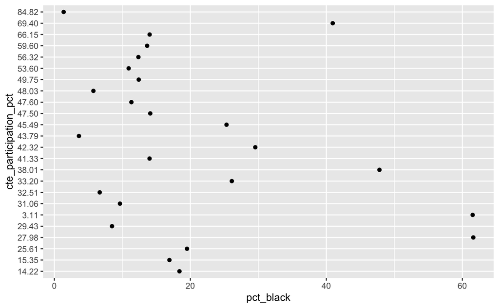

```r
ggplot(ed_data_demographics_total, aes(x=pct_black, y=cte_participation_pct)) +
  geom_point()
```

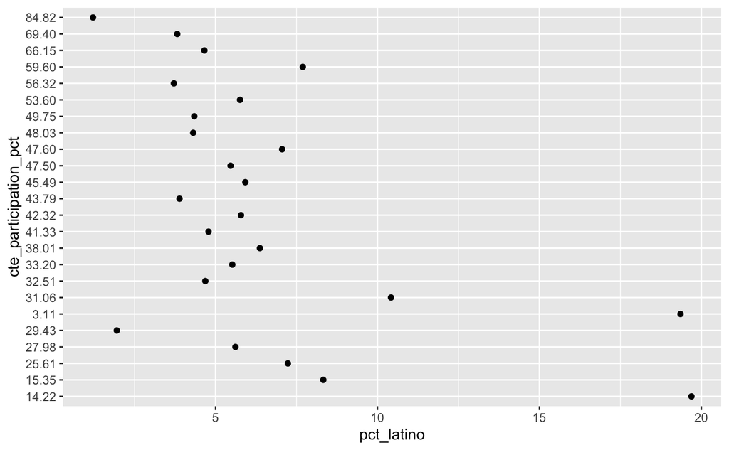

```r
ggplot(ed_data_demographics_total, aes(x=pct_latino, y=cte_participation_pct)) +
  geom_point()
```

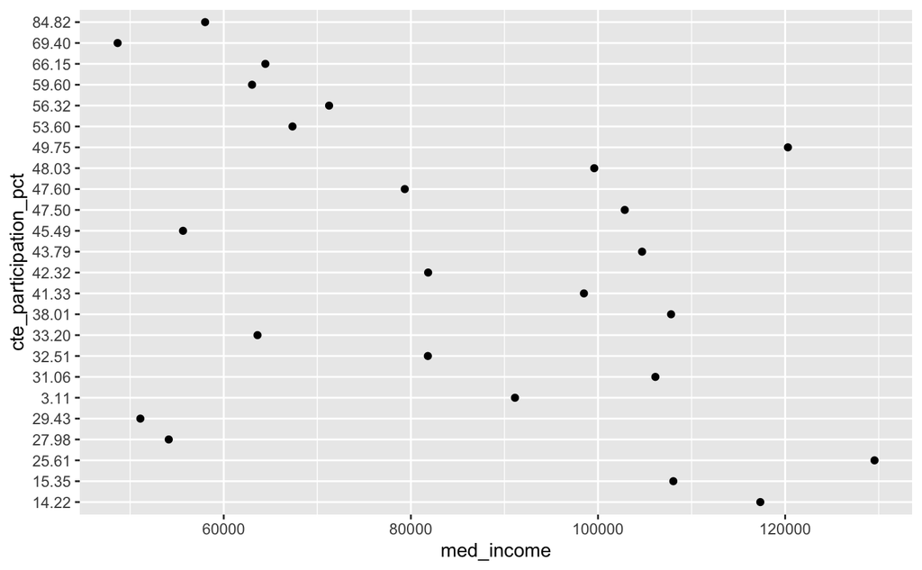

```r
ggplot(ed_data_demographics_total, aes(x=med_income, y=cte_participation_pct)) +
  geom_point()
```

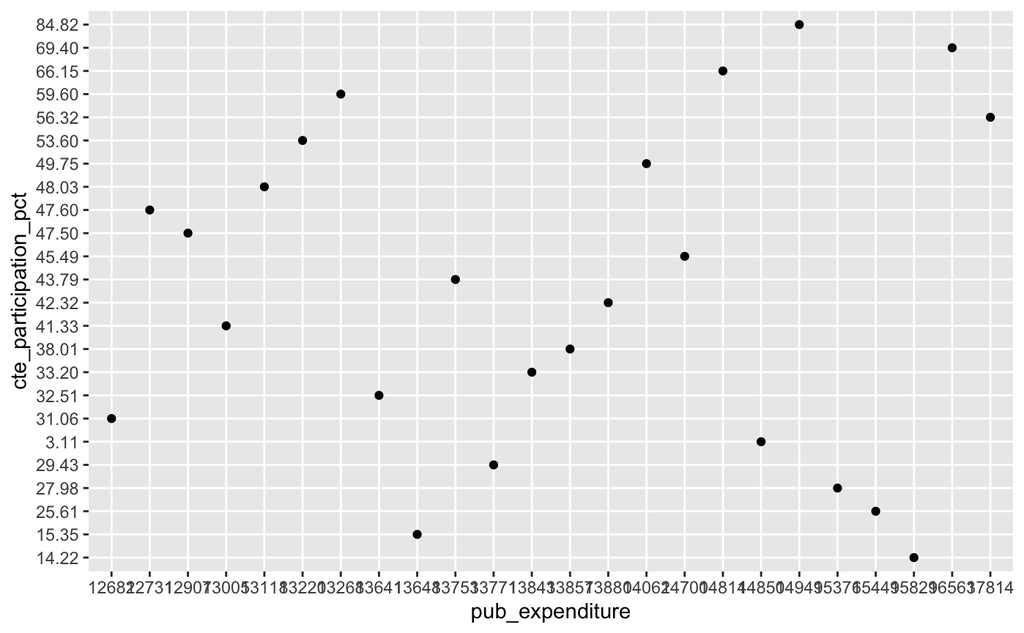

```r
ggplot(ed_data_demographics_total, aes(x=pub_expenditure, y=cte_participation_pct)) +
  geom_point()
```

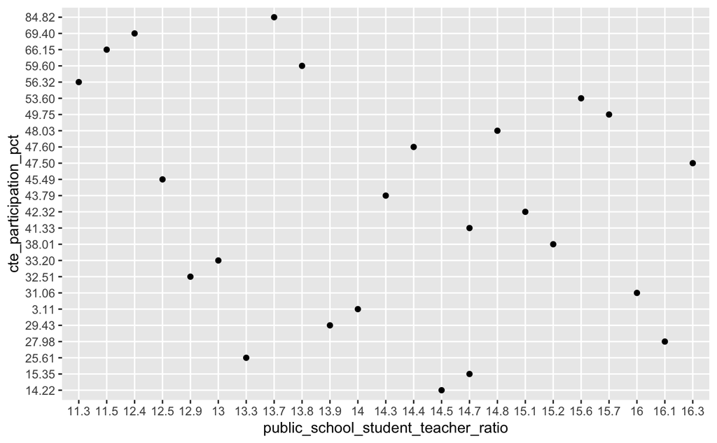

```r
ggplot(ed_data_demographics_total, aes(x=public_school_student_teacher_ratio, y=cte_participation_pct)) +
  geom_point()
```

There’s sort of a relationship but it doesn’t look like it’s super strong.

Now let’s look at the racial demographics of counties with high college enrollment.

```r
ggplot(ed_data_demographics_total, aes(x=pct_white, y=college_enroll_pct_24mos_19)) +
  geom_point()

ggplot(ed_data_demographics_total, aes(x=pct_black, y=college_enroll_pct_24mos_19)) +
  geom_point()

ggplot(ed_data_demographics_total, aes(x=pct_latino, y=college_enroll_pct_24mos_19)) +
  geom_point()

ggplot(ed_data_demographics_total, aes(x=med_income, y=college_enroll_pct_24mos_19)) +
  geom_point()

ggplot(ed_data_demographics_total, aes(x=pub_expenditure, y=college_enroll_pct_24mos_19)) +
  geom_point()

ggplot(ed_data_demographics_total, aes(x=public_school_student_teacher_ratio, y=college_enroll_pct_24mos_19)) +
  geom_point()
```

[output not shown]

I think I need to look at CTE rates over time. let’s import the full cte data and join it to our dataset.

```r
full_cte <- read_csv("cte_participation_cleaned.csv") |>
  clean_names()

ed_data_demographics_cte_total <- ed_data_demographics_total |> inner_join (full_cte, join_by(county)) |>
  rename(cte18 = x2018_cte) |>
  rename(cte19 = x2019_cte) |>
  rename(cte20 = x2020_cte) |>
  rename(cte21 = x2021_cte) |>
  rename(cte22 = x2022_cte)

#not sure why this wouldn't run with all these renames in the same function

cte_changes <- ed_data_demographics_cte_total |> select(county, cte18, cte22) |>
mutate(cte18 = str_remove_all(cte18, "%"), cte22 = str_remove_all(cte22, "%")) |>
  mutate(cte18 = as.numeric(cte18), cte22 = as.numeric(cte22))

cte_changes <- cte_changes |>
  mutate(cte_change = cte22-cte18)

#it was giving me a weird error message so I asked chatgpt for help. sent it my code and my error message Error: unexpected symbol in:
#"mutate(as.numeric(cte18, cte22)
#cte_changes" - it told me I was doing my mutate wrong and I felt dumb for asking
```

```r
cte_changes |>
  arrange(desc(cte_change))
```

[output not shown]

```r
cte_changes |>
  arrange(cte_change)
```

[output not shown]

Let’s make a bar graph of this.

```r
write_csv(cte_changes, "cte_changes.csv")
knitr::include_graphics("cte_participation_growth.png")
```

[output not shown]

Story Idea 2: Lower-income counties tend to have higher CTE participation rates for high schoolers. I’d like to find out what the top programs are for these areas, what these students are interested in pursuing, how they chose their career path, etc. Students from higher-income counties are more likely to go to college (this is sort of a no brainer). However, there is often a lack of education for students, especially those from lower-income communities, on how they can make college affordable. I’d like to look at what barriers students from lower-income communities face in going to college and why they chose CTE over college. For our article on the college and career readiness pillar of the blueprint, I’d also like to look at if and how career counselors plan on addressing college affordability to help students make more informed choices about college.

Note to Derek: I realized I would have been much better off looking at data I could play with more than aggregate data. Sorry my data anaylsis is lacking - I went into this with the mindset of wanted to see how different factors impact each other, which I think I did, but I now see why you wanted us to have more data rows. On the bright side, I definitely got some good information for my blueprint article!